# Module-10

```r
library(curl)
f <- curl("https://raw.githubusercontent.com/fuzzyatelin/fuzzyatelin.github.io/master/AN597_Fall17/vervet-weights.csv")
d <- read.csv(f, header = TRUE, sep = ",", stringsAsFactors = FALSE)
head(d)
```

```
##   id weight
## 1  1   5.17
## 2  2   7.13
## 3  3   4.70
## 4  4   6.10
## 5  5   6.36
## 6  6   4.93
```

```r
mean(d$weight)
```

```
## [1] 5.323922
```

Ho is that the mean is equal to 4.9 Ha is the mean is greater than 4.9 This is a upper-tailed test lets now test the mean, sd and SEM of the sample

```r
mu <- 4.9
x <- d$weight
m <- mean(x)
m
```

```
## [1] 5.323922
```

```r
s <- sd(x)
s
```

```
## [1] 0.9754016
```

```r
n <- length(x)
sem <- s/sqrt(n)
sem
```

```
## [1] 0.1365835
```

above are the mean, sd ad sem

```r
z <- (m - mu)/sem
z
```

```
## [1] 3.103753
```

this is our z score, it is the estimated number of standard errors of the mean away from the population mean that our sample falls

```r
p <- 1 - pnorm(z)
p
```

```
## [1] 0.0009554144
```

this is ouur p value

```r
p <- pnorm(z, lower.tail = FALSE)
p
```

```
## [1] 0.0009554144
```

we use this because we want the upper part not the lower becasue our sample is limmited, we will use the t distrabution

```r
p <- 1 - pt(z, df = n - 1)
p
```

```
## [1] 0.001570945
```

this is the p value for t disrtabution

```r
p <- pt(z, df = n - 1, lower.tail = FALSE)
p
```

```
## [1] 0.001570945
```

```r
t <- t.test(x = x, mu = mu, alternative = "greater")
t
```

```
##
##  One Sample t-test
##
## data:  x
## t = 3.1038, df = 50, p-value = 0.001571
## alternative hypothesis: true mean is greater than 4.9
## 95 percent confidence interval:
##  5.095021      Inf
## sample estimates:
## mean of x
##  5.323922
```

this means we reject the Ho and the mean is differnt this year.

```r
lower <- m - qt(1 - 0.05/2, df = n - 1) * sem
upper <- m + qt(1 - 0.05/2, df = n - 1) * sem
ci <- c(lower, upper)
ci
```

```
## [1] 5.049585 5.598258
```

this is calulating the CI bby hand

```r
t <- t.test(x = x, mu = mu, alternative = "two.sided")
ci <- t$conf.int
ci
```

```
## [1] 5.049585 5.598258
## attr(,"conf.level")
## [1] 0.95
```

this iscalculating the CI with R built in functions

For this question about woolly monkeys, Ho is the mean weight is 7.2kg and Ha is the mean weight is not 7.2kg

```r
f <- curl("https://raw.githubusercontent.com/fuzzyatelin/fuzzyatelin.github.io/master/AN597_Fall17/woolly-weights.csv")
d <- read.csv(f, header = TRUE, sep = ",", stringsAsFactors = FALSE)
head(d)
```

```
##   id weight
## 1  1   6.14
## 2  2   6.19
## 3  3   7.08
## 4  4   5.67
## 5  5   4.83
## 6  6   6.83
```

```r
x <- d$weight
m <- mean(x)
s <- sd(x)
n <- length(x)
sem <- s/sqrt(n)
mu <- 7.2
t <- (m - mu)/sem
t
```

```
## [1] -3.336805
```

here ge got our t statistic by hand

```r
alpha <- 0.05
crit <- qt(1 - alpha/2, df = n - 1)  # identify critical values
test <- t < -crit || t > crit  # boolean test as two whether t is larger than the critical value at either tail
test <- abs(t) > crit
t.test(x = x, mu = mu, alternative = "two.sided")
```

```
##
##  One Sample t-test
##
## data:  x
## t = -3.3368, df = 14, p-value = 0.004891
## alternative hypothesis: true mean is not equal to 7.2
## 95 percent confidence interval:
##  5.930689 6.923978
## sample estimates:
## mean of x
##  6.427333
```

here we got our T test using the built in t-tester in R here we reject Ho #Comparing Sample Means: Two Sample Z and T Tests

```r
f <- curl("https://raw.githubusercontent.com/fuzzyatelin/fuzzyatelin.github.io/master/AN597_Fall17/colobus-weights.csv")
d <- read.csv(f, header = TRUE, sep = ",", stringsAsFactors = FALSE)
head(d)
```

```
##   id weight  sex
## 1  1   7.24 male
## 2  2   6.09 male
## 3  3   6.97 male
## 4  4   6.98 male
## 5  5   6.08 male
## 6  6   6.22 male
```

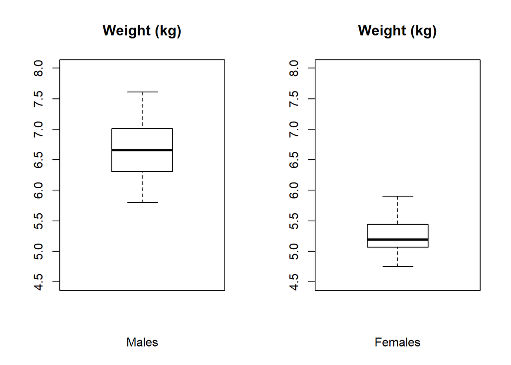

```r
x <- d$weight[d$sex == "male"]
y <- d$weight[d$sex == "female"]
par(mfrow = c(1, 2))
boxplot(x, ylim = c(4.5, 8), main = "Weight (kg)", xlab = "Males")
boxplot(y, ylim = c(4.5, 8), main = "Weight (kg)", xlab = "Females")
```

```r
m1 <- mean(x)
m2 <- mean(y)
mu <- 0  # you could leave this out... the default argument value is 0
s1 <- sd(x)
s2 <- sd(y)
n1 <- length(x)
n2 <- length(y)
```

```r
t <- (m2 - m1 - mu)/sqrt(s2^2/n2 + s1^2/n1)
t
```

```
## [1] -11.45952
```

here is our t statistic

```r
alpha <- 0.05
crit <- qt(1 - alpha/2, df = n - 1)  # identify critical values
crit
```

```
## [1] 2.144787
```

this is the critical value

```r
test <- t < -crit || t > crit  # boolean test
test <- abs(t) > crit
test
```

```
## [1] TRUE
```

```r
df <- (s2^2/n2 + s1^2/n1)^2/((s2^2/n2)^2/(n2 - 1) + (s1^2/n1)^2/(n1 - 1))
df
```

```
## [1] 31.21733
```

calculating df is differnt here

```r
t <- t.test(x = x, y = y, mu = 0, alternative = "two.sided")
t
```

```
##
##  Welch Two Sample t-test
##
## data:  x and y
## t = 11.46, df = 31.217, p-value = 1.023e-12
## alternative hypothesis: true difference in means is not equal to 0
## 95 percent confidence interval:
##  1.191186 1.706814
## sample estimates:
## mean of x mean of y
##     6.689     5.240
```

here we use the t-test built in function here we reject Ho becaue 0 is not in the CI #Samples with Equal Variances

```r
s <- sqrt((((n1 - 1) * s1^2) + ((n2 - 1) * s2^2))/(n1 + n2 - 2))
t <- (m2 - m1 - mu)/(sqrt(s^2 * (1/n1 + 1/n2)))
t
```

```
## [1] -11.45952
```

this is our t-statistic

```r
df <- n1 + n2 - 2
df
```

```
## [1] 38
```

this is the df

```r
t <- t.test(x = x, y = y, mu = 0, var.equal = TRUE, alternative = "two.sided")
t
```

```
##
##  Two Sample t-test
##
## data:  x and y
## t = 11.46, df = 38, p-value = 6.787e-14
## alternative hypothesis: true difference in means is not equal to 0
## 95 percent confidence interval:
##  1.193025 1.704975
## sample estimates:
## mean of x mean of y
##     6.689     5.240
```

```r
var(x)/var(y)
```

```
## [1] 2.746196
```

beacuse this ratio is greater than 2 we must use a F test to see in our var are equale or not

```r
vt <- var.test(x, y)
vt
```

```
##
##  F test to compare two variances
##
## data:  x and y
## F = 2.7462, num df = 19, denom df = 19, p-value = 0.03319
## alternative hypothesis: true ratio of variances is not equal to 1
## 95 percent confidence interval:
##  1.086978 6.938128
## sample estimates:
## ratio of variances
##           2.746196
```

hreject Ho, var1 not = to var2 #Paired Samples

```r
f <- curl("https://raw.githubusercontent.com/fuzzyatelin/fuzzyatelin.github.io/master/AN597_Fall17/iqs.csv")
d <- read.csv(f, header = TRUE, sep = ",", stringsAsFactors = FALSE)
head(d)
```

```
##   id IQ.before IQ.after
## 1  1    124.54   133.50
## 2  2    125.98   131.93
## 3  3    126.93   129.15
## 4  4    114.93   129.38
## 5  5    122.41   132.77
## 6  6    123.64   126.80
```

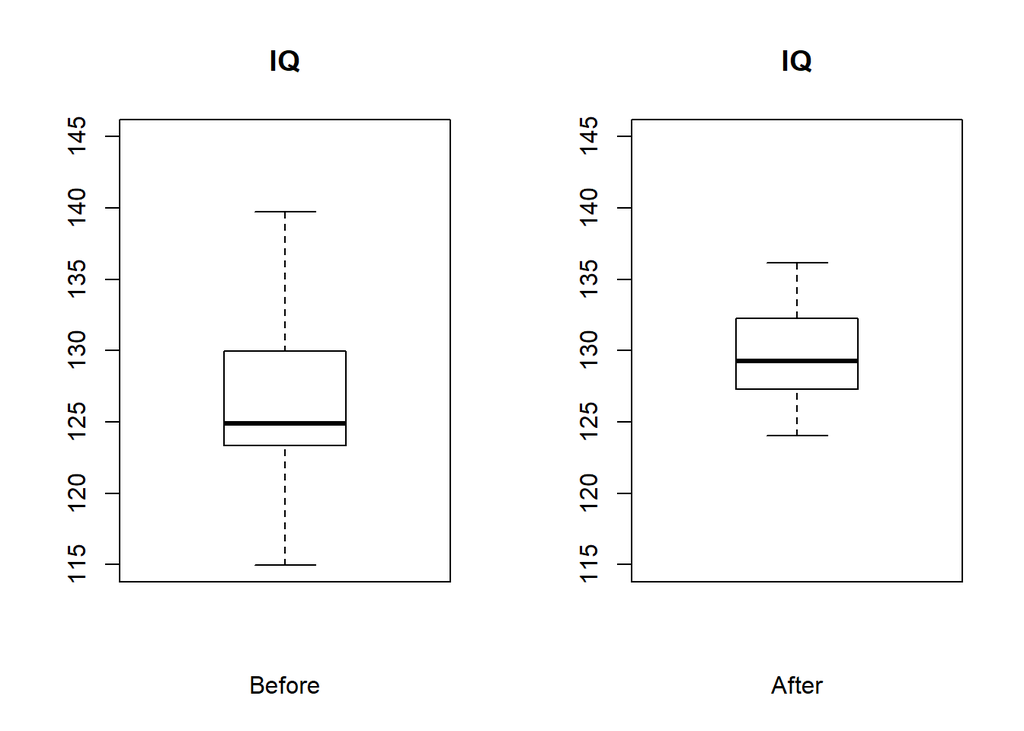

```r
x <- d$IQ.before - d$IQ.after
m <- mean(x)
mu <- 0  # can leave this out
s <- sd(x)
n <- length(x)
sem <- s/sqrt(n)
par(mfrow = c(1, 2))
boxplot(d$IQ.before, ylim = c(115, 145), main = "IQ", xlab = "Before")
boxplot(d$IQ.after, ylim = c(115, 145), main = "IQ", xlab = "After")
```

```r
t <- (m - mu)/sem
t
```

```
## [1] -1.789636
```

```r
alpha <- 0.05
crit <- qt(1 - alpha/2, df = n - 1)  # identify critical values
crit
```

```
## [1] 2.093024
```

```r
test <- t < -crit || t > crit  # boolean test
test
```

```
## [1] FALSE
```

```r
t.test(x, df = n - 1, alternative = "two.sided")
```

```
##
##  One Sample t-test
##
## data:  x
## t = -1.7896, df = 19, p-value = 0.08946
## alternative hypothesis: true mean is not equal to 0
## 95 percent confidence interval:
##  -6.762409  0.528409
## sample estimates:
## mean of x
##    -3.117
```

```r
pop <- c(rep(0, 500), rep(1, 500))
```

here we created a population of 500 1s and 500 0s

```r
pi <- 0.5
x <- NULL
n <- 10
for (i in 1:1000) {
    x[i] <- mean(sample(pop, size = n, replace = FALSE))  # taking the mean of a bunch of 0s and 1s yields the proportion of 1s!
}
m <- mean(x)
m
```

```
## [1] 0.5031
```

this is the population mean

```r
s <- sd(x)
s
```

```
## [1] 0.1539613
```

this is the population sd

```r
pop_se <- sqrt(pi * (1 - pi)/n)
pop_se
```

```
## [1] 0.1581139
```

this is the population se

```r
pop <- c(rep(0, 800), rep(1, 200))
pi <- 0.8
x <- NULL
n <- 10
for (i in 1:1000) {
    x[i] <- mean(sample(pop, size = n, replace = FALSE))  # taking the mean of a bunch of 0s and 1s yields the proportion of 1s!
}
m <- mean(x)
m
```

```
## [1] 0.1974
```

```r
s <- sd(x)
s
```

```
## [1] 0.1317976
```

this is pop sd

```r
pop_se <- sqrt(pi * (1 - pi)/n)
pop_se
```

```
## [1] 0.1264911
```

this is pop se

# challenge for neotropical ornithologist

Ho is p is equal to 80% Ha is p is less than 80%

```r
30*.8
```

```
## [1] 24
```

```r
30*(1-.8)
```

```
## [1] 6
```

both are greater than 5 so we may continue

```r
v <- c(0, 1, 1, 1, 0, 1, 0, 0, 1, 1, 0, 0, 1, 1, 0, 1, 1, 0, 0, 1, 1, 1, 0,
    1, 1, 0, 1, 0, 1, 1)
```

these are the results

```r
phat <- mean(v)
phat
```

```
## [1] 0.6
```

this is the test statistic

```r
pi <- 0.8
n <- 30
z <- (phat - pi)/sqrt(pi * (1 - pi)/30)
z
```

```
## [1] -2.738613
```

this is the z value

```r
p <- pnorm(z, lower.tail = TRUE)
p
```

```
## [1] 0.00308495
```

```r
lower <- phat - qnorm(0.975) * sqrt(phat * (1 - phat)/30)
upper <- phat + qnorm(0.975) * sqrt(phat * (1 - phat)/30)
ci <- c(lower, upper)
ci
```

```
## [1] 0.4246955 0.7753045
```

this is the CI from this data we reject Ho becasue pi is not in the CI

```r
pt <- prop.test(x = sum(v), n = length(v), p = 0.8, conf.level = 0.95, correct = FALSE,
    alternative = "less")
pt
```

```
##
##  1-sample proportions test without continuity correction
##
## data:  sum(v) out of length(v), null probability 0.8
## X-squared = 7.5, df = 1, p-value = 0.003085
## alternative hypothesis: true p is less than 0.8
## 95 percent confidence interval:
##  0.0000000 0.7328738
## sample estimates:
##   p
## 0.6
```

we use the built in R function and get the same result #Comparing Sample Proportions: Two Sample Z Tests testing bats challange

```r
v1 <- c(1, 0, 1, 1, 0, 0, 1, 1, 0, 0, 1, 1, 1, 1, 0, 0, 1, 1, 0, 0, 1, 1, 0,
    1, 0)
v2 <- c(1, 1, 0, 0, 1, 1, 1, 1, 0, 1, 0, 1, 1, 1, 0, 1, 0, 1, 1, 1, 1, 1, 0,
    0, 1, 1, 0, 1, 1, 1)
```

Ho is mean1-mean2=0, Ha is mean1-mean2 does not = 0

```r
pstar <- (sum(v1) + sum(v2))/(length(v1) + length(v2))
pstar
```

```
## [1] 0.6363636
```

```r
phat1 <- mean(v1)
phat1
```

```
## [1] 0.56
```

test statistic for v1

```r
phat2 <- mean(v2)
phat2
```

```
## [1] 0.7
```

test statistic for v2

```r
pi <- 0
z <- (phat2 - phat1)/sqrt((pstar * (1 - pstar)) * (1/length(v1) + 1/length(v2)))
z
```

```
## [1] 1.074709
```

this is the z avalue

```r
p <- 1 - pnorm(z, lower.tail = TRUE) + pnorm(z, lower.tail = FALSE)
p
```

```
## [1] 0.2825049
```

```r
crit <- qnorm(1 - alpha/2)  # identify critical values
crit
```

```
## [1] 1.959964
```

this gives the critical value

```r
test <- p < -crit || p > crit  # boolean test
test
```

```
## [1] FALSE
```

```r
pt <- prop.test(x = c(sum(v2), sum(v1)), n = c(length(v2), length(v1)), alternative = "two.sided",
    correct = FALSE)
pt
```

```
##
##  2-sample test for equality of proportions without continuity
##  correction
##
## data:  c(sum(v2), sum(v1)) out of c(length(v2), length(v1))
## X-squared = 1.155, df = 1, p-value = 0.2825
## alternative hypothesis: two.sided
## 95 percent confidence interval:
##  -0.1144634  0.3944634
## sample estimates:
## prop 1 prop 2
##   0.70   0.56
```

I think these results mean that v1 and v2 are equal to eachother b/c 0 is in the CI so do not reject Ho